# Matou_Project2_Part2

```python
# Importing Packages
import numpy as np
import pandas as pd
import matplotlib as plt
import seaborn as sns
import matplotlib.pyplot as plt
from PIL import Image
import sys
```

```python
# Importing the Revised Data from Part 1
df = pd.read_csv('Lit2.csv')
df
```

|  | index | Region | Country | Year | Age | Gender | Literacy rate | Percentage | Literacy Health |
| --- | --- | --- | --- | --- | --- | --- | --- | --- | --- |
| 0 | 0 | Central and Southern Asia | Afghanistan | 2011 | 15+ | female | 0.176121 | 18.0 | Illiterate |
| 1 | 1 | Central and Southern Asia | Afghanistan | 2011 | 15+ | male | 0.454171 | 45.0 | Average Literacy |
| 2 | 2 | Central and Southern Asia | Afghanistan | 2011 | 15+ | total | 0.317411 | 32.0 | Slightly Literate |
| 3 | 3 | Central and Southern Asia | Afghanistan | 2011 | 15-24 | female | 0.321132 | 32.0 | Slightly Literate |
| 4 | 4 | Central and Southern Asia | Afghanistan | 2011 | 15-24 | male | 0.618791 | 62.0 | Good Literacy |
| ... | ... | ... | ... | ... | ... | ... | ... | ... | ... |
| 4950 | 4950 | Sub-Saharan Africa | Zimbabwe | 2014 | 25-64 | male | 0.897255 | 90.0 | Excellent Literacy |
| 4951 | 4951 | Sub-Saharan Africa | Zimbabwe | 2014 | 25-64 | total | 0.887874 | 89.0 | Excellent Literacy |
| 4952 | 4952 | Sub-Saharan Africa | Zimbabwe | 2014 | 65+ | female | 0.734258 | 73.0 | Good Literacy |
| 4953 | 4953 | Sub-Saharan Africa | Zimbabwe | 2014 | 65+ | male | 0.927231 | 93.0 | Excellent Literacy |
| 4954 | 4954 | Sub-Saharan Africa | Zimbabwe | 2014 | 65+ | total | 0.811269 | 81.0 | Excellent Literacy |

4955 rows × 9 columns

```python
# Creating a new variable before manipulating the dataframe
litr = df.copy()
litr
```

|  | index | Region | Country | Year | Age | Gender | Literacy rate | Percentage | Literacy Health |
| --- | --- | --- | --- | --- | --- | --- | --- | --- | --- |
| 0 | 0 | Central and Southern Asia | Afghanistan | 2011 | 15+ | female | 0.176121 | 18.0 | Illiterate |
| 1 | 1 | Central and Southern Asia | Afghanistan | 2011 | 15+ | male | 0.454171 | 45.0 | Average Literacy |
| 2 | 2 | Central and Southern Asia | Afghanistan | 2011 | 15+ | total | 0.317411 | 32.0 | Slightly Literate |
| 3 | 3 | Central and Southern Asia | Afghanistan | 2011 | 15-24 | female | 0.321132 | 32.0 | Slightly Literate |
| 4 | 4 | Central and Southern Asia | Afghanistan | 2011 | 15-24 | male | 0.618791 | 62.0 | Good Literacy |
| ... | ... | ... | ... | ... | ... | ... | ... | ... | ... |
| 4950 | 4950 | Sub-Saharan Africa | Zimbabwe | 2014 | 25-64 | male | 0.897255 | 90.0 | Excellent Literacy |
| 4951 | 4951 | Sub-Saharan Africa | Zimbabwe | 2014 | 25-64 | total | 0.887874 | 89.0 | Excellent Literacy |
| 4952 | 4952 | Sub-Saharan Africa | Zimbabwe | 2014 | 65+ | female | 0.734258 | 73.0 | Good Literacy |
| 4953 | 4953 | Sub-Saharan Africa | Zimbabwe | 2014 | 65+ | male | 0.927231 | 93.0 | Excellent Literacy |
| 4954 | 4954 | Sub-Saharan Africa | Zimbabwe | 2014 | 65+ | total | 0.811269 | 81.0 | Excellent Literacy |

4955 rows × 9 columns

```python
# Deleting the index column as it does not provide much information
litr.drop('index', axis =1, inplace= True)
litr
```

|  | Region | Country | Year | Age | Gender | Literacy rate | Percentage | Literacy Health |
| --- | --- | --- | --- | --- | --- | --- | --- | --- |
| 0 | Central and Southern Asia | Afghanistan | 2011 | 15+ | female | 0.176121 | 18.0 | Illiterate |
| 1 | Central and Southern Asia | Afghanistan | 2011 | 15+ | male | 0.454171 | 45.0 | Average Literacy |
| 2 | Central and Southern Asia | Afghanistan | 2011 | 15+ | total | 0.317411 | 32.0 | Slightly Literate |
| 3 | Central and Southern Asia | Afghanistan | 2011 | 15-24 | female | 0.321132 | 32.0 | Slightly Literate |
| 4 | Central and Southern Asia | Afghanistan | 2011 | 15-24 | male | 0.618791 | 62.0 | Good Literacy |
| ... | ... | ... | ... | ... | ... | ... | ... | ... |
| 4950 | Sub-Saharan Africa | Zimbabwe | 2014 | 25-64 | male | 0.897255 | 90.0 | Excellent Literacy |
| 4951 | Sub-Saharan Africa | Zimbabwe | 2014 | 25-64 | total | 0.887874 | 89.0 | Excellent Literacy |
| 4952 | Sub-Saharan Africa | Zimbabwe | 2014 | 65+ | female | 0.734258 | 73.0 | Good Literacy |
| 4953 | Sub-Saharan Africa | Zimbabwe | 2014 | 65+ | male | 0.927231 | 93.0 | Excellent Literacy |
| 4954 | Sub-Saharan Africa | Zimbabwe | 2014 | 65+ | total | 0.811269 | 81.0 | Excellent Literacy |

4955 rows × 8 columns

I first did a pie chart that looks at the overall literacy percentages based on the dataframe.

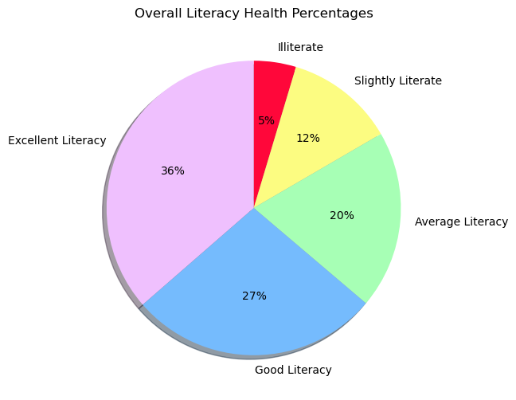

```python
books = litr.groupby('Literacy Health')['Percentage'].mean().sort_values() #Sorts values from Illiterate to Excellent Literacy
colors = ['xkcd:neon red',  "xkcd:yellowish tan", 'xkcd:light seafoam green','xkcd:sky blue', 'xkcd:light lavendar']
plt.figure(figsize=(10,6))
# Creating a pie chart
plt.pie(books, labels=books.index,
    colors=colors,
    autopct='%1.0f%%', #Indicates the specified decimals you want; in this case, 0
    startangle=90,
    shadow=True,
    counterclock=False)
plt.title('Overall Literacy Health Percentages')
plt.savefig('PieLit.jpg')
plt.show()
```

### **Section 1**

#### Question 1

I did was a boxplot that showcased the median literacy rate across age groups.

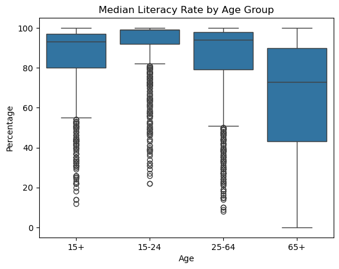

```python
sns.boxplot(x = 'Age', y= 'Percentage', data= litr)
plt.title('Median Literacy Rate by Age Group')
plt.savefig('BoxLit.jpg')
plt.show()
```

The boxplot reveals that:

- The 15-24 sectionhad the most outliers even though it had the most concentrated data.
- The box plots for the 15+ and 25-64 age groups had similar whisker length and were roughly close to the same median and number of outliers.
- The 65+ group has no outliers but the lowest whisker (all the way at 0) compared to the other groups.

The next graph I did was a countplot to see the number of times each classifcation of literacy health showed across the sampled years, 2010-2018.

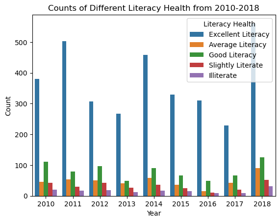

```python
# Creating a Count Plot
reads = sns.countplot(x='Year', hue = 'Literacy Health', data = litr) #litr = variable name for dataset

# Add a title
plt.title('Counts of Different Literacy Health from 2010-2018')
plt.ylabel("Count")
plt.savefig('CountLit.jpg')
plt.show()
```

This visualization showed me that through the sampled years, there are many high counts of Excellent Literacy health, with 2018 having the most. The lowest was 2017, and then sky rocketing in 2018, causing me to question why there was such a jump in only a year.

#### Question 2

I did a bar plot that compared the literacy rate across the different regions because doing the chart by country would have made it confusing to read and interpret because of the many countries in this dataframe.

```python
group = (litr.groupby('Region')['Literacy rate'].mean()*100).round().sort_values(ascending=False, inplace=False)
group
```

```
Region
Europe and Northern America         98.0
Oceania                             91.0
Latin America and the Caribbean     91.0
Eastern and South-Eastern Asia      88.0
Northern Africa and Western Asia    85.0
Central and Southern Asia           72.0
Sub-Saharan Africa                  62.0
Name: Literacy rate, dtype: float64
```

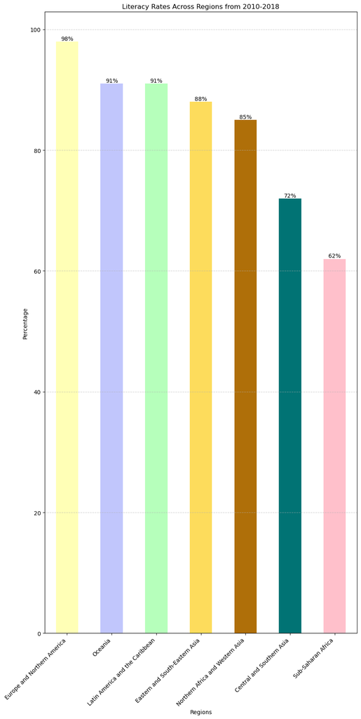

```python
plt.figure(figsize=(10,20))
read = group.plot(kind='bar', color = ['xkcd:creme','xkcd:light periwinkle', 'xkcd:light mint', 'xkcd:light gold', 'xkcd:caramel', 'xkcd:deep turquoise', 'pink'])
plt.title('Literacy Rates Across Regions from 2010-2018')
plt.xlabel('Regions')
plt.ylabel('Percentage')
plt.xticks(rotation=45, ha = 'right')
plt.grid(axis='y', linestyle='--', alpha=0.6)
for i, v in enumerate(group):
    read.text(i, v+.01,
            f"{v:.0f}%",
            ha='center', va='bottom')
plt.savefig('BarLit.jpg')
plt.show()
```

One big difference was Sub-Saharan Africa having the lowest literacy percentage, leading me to question the real world context behind why that is the case.

# Section 2

I did a scatterplot that showcases the literacy percentage by region separated by gender to see if there is a relationship between one's gender, region, and subsequent literacy.

```python
groupm = litr.groupby('Gender')
y = (groupm.get_group('male'))
```

```python
groupf = litr.groupby('Gender')
x = (groupf.get_group('female'))
```

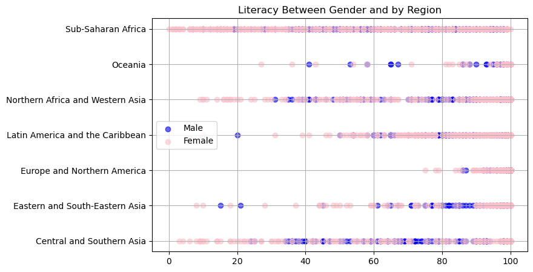

```python
plt.figure(figsize=(8, 5))
male= litr['Gender'] == 'male'
female = litr['Gender'] == 'female'
plt.scatter(y['Percentage'][male], y['Region'][male],
            color='blue', alpha=0.6, label='Male')
plt.scatter(x['Percentage'][female], x['Region'][female],
            color='pink', alpha=0.6, label='Female')

plt.legend()
plt.grid(True)

plt.title('Literacy Between Gender and by Region')
plt.savefig('ScatLit.jpg')
plt.show()
```

Beceause it was hard to read, I split the scatterplot in two.

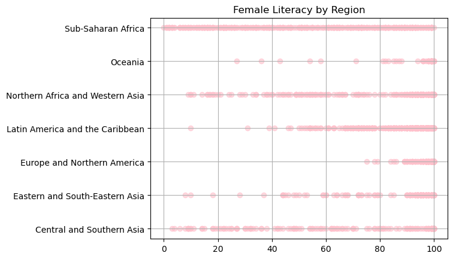

```python
female = litr['Gender'] == 'female'
plt.scatter(x['Percentage'][female], x['Region'][female],
            color='pink', alpha=0.6, label='Female')

plt.grid(True)

plt.title('Female Literacy by Region')
plt.savefig('ScatLitF.jpg')
plt.show()
```

For females in both Sub-Saharan Africa and Central and Southern Asia, their literacy rate spanned from zero to 100 percent.

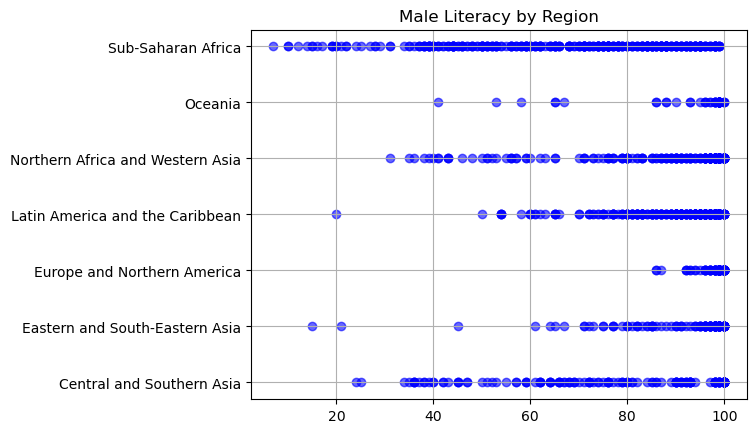

```python
male= litr['Gender'] == 'male'
plt.scatter(y['Percentage'][male], y['Region'][male],
            color='blue', alpha=0.6, label='Male')

plt.grid(True)

plt.title('Male Literacy by Region')
plt.savefig('ScatLitM.jpg')
plt.show()
```

Even though there are a few outliers, most male literacy rates are above 20% while for females it is around 10 - 15%, showing that there is a literacy gap by gender.

To summarize the insights, there is a correlation between age, gender, and country/region in relation to one’s literacy rate. More research is required to look into the real world context surrounding this data and the above findings.